# Bayesian modeling and prediction for movies

Raymond Ngiam

06 Aug 2016

## Setup

### Load packages

```r
library(ggplot2)
library(dplyr)
library(statsr)
library(BAS)
library(GGally)
library(MASS)
library(pander)
```

### Load data

```r
load("movies.Rdata")
```

## Part 1: Data

**How the observations in the sample are collected:**

The data set is comprised of 651 randomly sampled movies produced and released before 2016 [1].

**Implications of this data collection method on the scope of inference (generalizability):**

Since the data collection involves random sampling, the sample can be considered representative of the population. Hence findings from this observational study can be generalized to the entire population.

**Implications of this data collection method on the scope of inference (causality):**

Since this is an observational study, not an experiment where subjects are randomly assigned for specific treatments, hence, the findings on relationship among different factors only establish association but do not imply causality.

## Part 2: Data manipulation

Entries with NA (Not Applicable) cell are removed from the dataset.

```r
movies_no_na <- na.omit(movies)
N = nrow(movies_no_na)
N
```

```
## [1] 619
```

New variables are created as follows:

- **feature_film**: “yes” if **title_type** is Feature Film, “no” otherwise
- **drama**: “yes” if **genre** is Drama, “no” otherwise
- **mpaa_rating_R**: “yes” if **mpaa_rating** is R, “no” otherwise
- **oscar_season**: “yes” if movie is released in November, October, or December (based on **thtr_rel_month**), “no” otherwise
- **summer_season**: “yes” if movie is released in May, June, July, or August (based on **thtr_rel_month**), “no” otherwise

```r
movies_added_predictors <- movies_no_na %>%
  mutate(feature_film = if_else(title_type=="Feature Film","yes","no")) %>%
  mutate(drama = if_else(genre=="Drama","yes","no")) %>%
  mutate(mpaa_rating_R = if_else(mpaa_rating=="R","yes","no")) %>%
  mutate(oscar_season = if_else(is.element(thtr_rel_month,c(10,11,12)),"yes","no")) %>%
  mutate(summer_season = if_else(is.element(thtr_rel_month,c(5,6,7,8)),"yes","no"))

movies_added_predictors$feature_film = factor(movies_added_predictors$feature_film, levels = c("yes", "no"))
movies_added_predictors$drama = factor(movies_added_predictors$drama, levels = c("yes", "no"))
movies_added_predictors$mpaa_rating_R = factor(movies_added_predictors$mpaa_rating_R, levels = c("yes", "no"))
movies_added_predictors$oscar_season = factor(movies_added_predictors$oscar_season, levels = c("yes", "no"))
movies_added_predictors$summer_season = factor(movies_added_predictors$summer_season, levels = c("yes", "no"))
```

## Part 3: Exploratory data analysis

We will consider the following variables in our bayesian model selection:

- **feature_film**
- **drama**
- **runtime**
- **mpaa_rating_R**
- **thtr_rel_year**
- **oscar_season**
- **summer_season**
- **imdb_rating**
- **imdb_num_votes**
- **critics_score**
- **best_pic_nom**
- **best_pic_win**
- **best_actor_win**
- **best_actress_win**
- **best_dir_win**
- **top200_box**

Firstly, lets explore the relationship between audience_score and the new categorical variables constructed in the previous part.

1. Feature film and audience score

Box plot to visualize the differences in audience score distribution among categorical variable, **feature_film**.

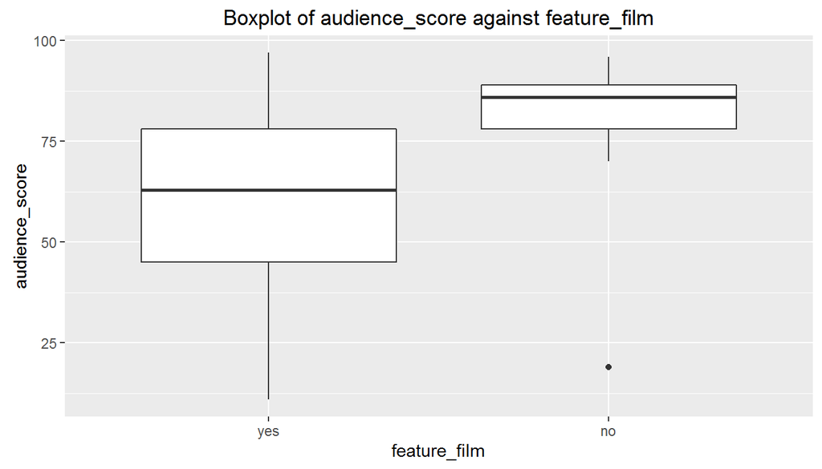

```r
ggplot(data=movies_added_predictors, aes(x=feature_film, y=audience_score)) +
  geom_boxplot() +
  labs(title = "Boxplot of audience_score against feature_film")
```

Summary statistics

```r
movies_added_predictors %>%
  group_by(feature_film) %>%
  summarize(mean=mean(audience_score), sd=sd(audience_score),median=median(audience_score),IQR=IQR(audience_score),min=min(audience_score),max=max(audience_score), count=n())
```

```
## # A tibble: 2 x 8
##   feature_film     mean       sd median   IQR   min   max count
##         <fctr>    <dbl>    <dbl>  <dbl> <dbl> <dbl> <dbl> <int>
## 1          yes 60.57766 19.81866     63    33    11    97   573
## 2           no 82.54348 11.91769     86    11    19    96    46
```

Interpretation: There is an obvious difference in the distribution of audience score between movies that belong to feature_film category and those that do not. The feature_film title type has lower audience score by 21.966 on average compared to the rest.

2. Drama and audience score

Box plot to visualize the differences in audience score distribution among categorical variable, **drama**.

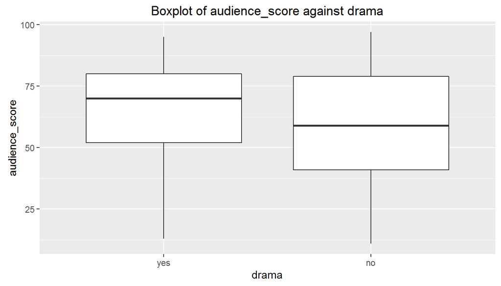

```r
ggplot(data=movies_added_predictors, aes(x=drama, y=audience_score)) +
  geom_boxplot() +
  labs(title = "Boxplot of audience_score against drama")
```

Summary statistics

```r
movies_added_predictors %>%
  group_by(drama) %>%
  summarize(mean=mean(audience_score), sd=sd(audience_score),median=median(audience_score),IQR=IQR(audience_score),min=min(audience_score),max=max(audience_score), count=n())
```

```
## # A tibble: 2 x 8
##    drama     mean       sd median   IQR   min   max count
##   <fctr>    <dbl>    <dbl>  <dbl> <dbl> <dbl> <dbl> <int>
## 1    yes 65.28859 18.63048     70    28    13    95   298
## 2     no 59.35202 21.14483     59    38    11    97   321
```

Interpretation: There is an obvious difference in the distribution of audience score between movies that belong to drama category and those that do not. The drama genre has higher audience score by 5.937 on average compared to the rest.

3. MPAA R Rating and audience score

Box plot to visualize the differences in audience score distribution among categorical variable, **mpaa_rating_R**.

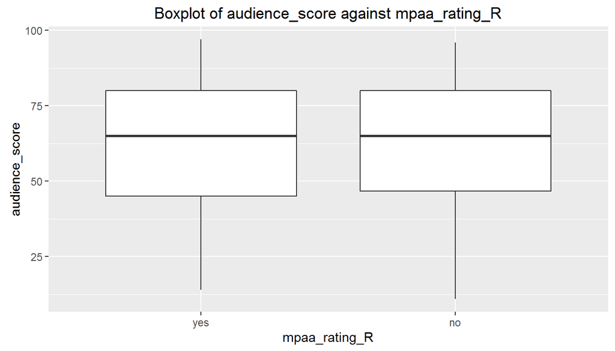

```r
ggplot(data=movies_added_predictors, aes(x=mpaa_rating_R, y=audience_score)) +
  geom_boxplot() +
  labs(title = "Boxplot of audience_score against mpaa_rating_R")
```

Summary statistics

```r
movies_added_predictors %>%
  group_by(mpaa_rating_R) %>%
  summarize(mean=mean(audience_score), sd=sd(audience_score),median=median(audience_score),IQR=IQR(audience_score),min=min(audience_score),max=max(audience_score), count=n())
```

```
## # A tibble: 2 x 8
##   mpaa_rating_R     mean       sd median   IQR   min   max count
##          <fctr>    <dbl>    <dbl>  <dbl> <dbl> <dbl> <dbl> <int>
## 1           yes 62.37304 20.07428     65 35.00    14    97   319
## 2            no 62.03667 20.31875     65 33.25    11    96   300
```

Interpretation: Apparently there is close to no difference in the distribution of audience score between movies that belong to mpaa_rating_R category and those that do not. The difference of average audience score between the two classes is only 0.336, hence it is not a significant predictor.

4. Oscar season and audience score

Box plot to visualize the differences in audience score distribution among categorical variable, **oscar_season**.

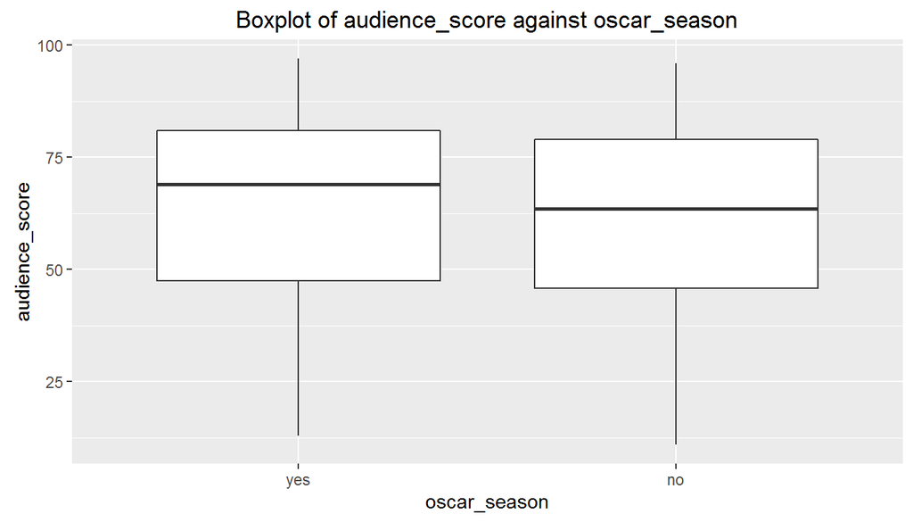

```r
ggplot(data=movies_added_predictors, aes(x=oscar_season, y=audience_score)) +
  geom_boxplot() +
  labs(title = "Boxplot of audience_score against oscar_season")
```

Summary statistics

```r
movies_added_predictors %>%
  group_by(oscar_season) %>%
  summarize(mean=mean(audience_score), sd=sd(audience_score),median=median(audience_score),IQR=IQR(audience_score),min=min(audience_score),max=max(audience_score), count=n())
```

```
## # A tibble: 2 x 8
##   oscar_season     mean       sd median   IQR   min   max count
##         <fctr>    <dbl>    <dbl>  <dbl> <dbl> <dbl> <dbl> <int>
## 1          yes 63.86034 20.31183   69.0 33.50    13    97   179
## 2           no 61.53864 20.10697   63.5 33.25    11    96   440
```

5. Summer season and audience score

Box plot to visualize the differences in audience score distribution among categorical variable, **summer_season**.

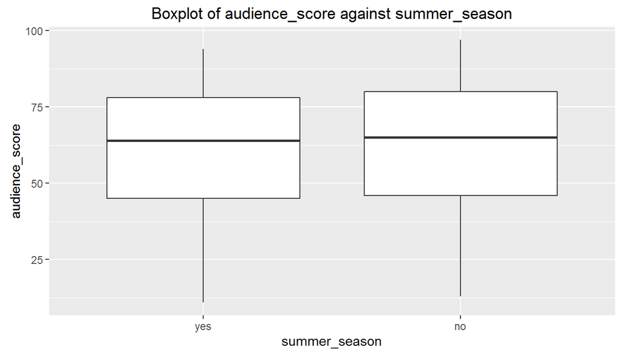

```r
ggplot(data=movies_added_predictors, aes(x=summer_season, y=audience_score)) +
  geom_boxplot() +
  labs(title = "Boxplot of audience_score against summer_season")
```

Summary statistics

```r
movies_added_predictors %>%
  group_by(summer_season) %>%
  summarize(mean=mean(audience_score), sd=sd(audience_score),median=median(audience_score),IQR=IQR(audience_score),min=min(audience_score),max=max(audience_score), count=n())
```

```
## # A tibble: 2 x 8
##   summer_season     mean       sd median   IQR   min   max count
##          <fctr>    <dbl>    <dbl>  <dbl> <dbl> <dbl> <dbl> <int>
## 1           yes 61.85075 19.90923     64    33    11    94   201
## 2            no 62.38278 20.32663     65    34    13    97   418
```

Interpretation: Apparently there is close to no difference in the distribution of audience score between movies that are released on summer_season and those that are not. The difference of average audience score between the two classes is only 0.532, hence it is not a significant predictor.

Next, we will analyze the numeric explanatory variables, namely **runtime**, **thtr_rel_year**, **imdb_rating**, **imdb_num_votes**, and **critics score**. Out of these five variables, **imdb_num_votes** is of particular interest.

Below is the histogram for the distribution of **imdb_num_votes**,

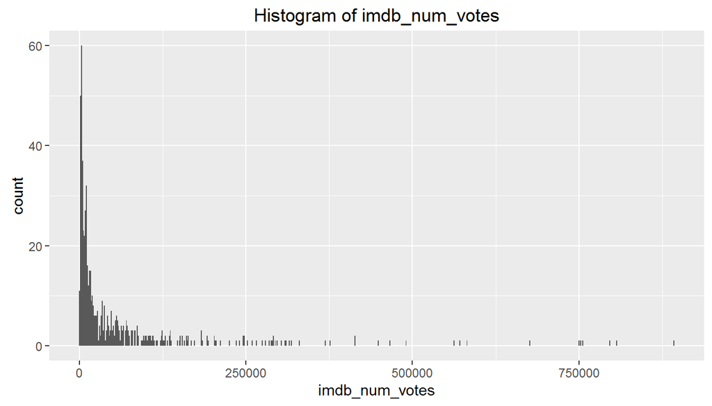

```r
ggplot(data = movies_added_predictors, aes(x=imdb_num_votes)) +
  geom_histogram(binwidth = 1500) +
  labs(title = "Histogram of imdb_num_votes")
```

```r
range(movies_added_predictors$imdb_num_votes)
```

```
## [1]    183 893008
```

The range of **imdb_num_votes** is (183, 893008), and it is heavily right-skewed. It will be more meaningful if we apply a log transformation, and name it as a new variable, **limdb_num_votes**.

```r
movies_added_predictors <- movies_added_predictors %>%
  mutate(limdb_num_votes = log10(imdb_num_votes))
```

Histogram of **limdb_num_votes**

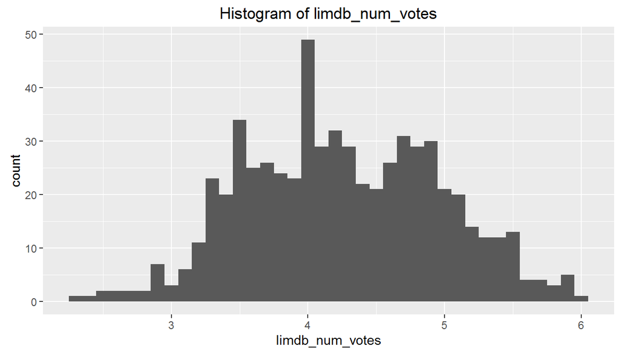

```r
ggplot(data = movies_added_predictors, aes(x=limdb_num_votes)) +
  geom_histogram(binwidth = 0.1) +
  labs(title = "Histogram of limdb_num_votes")
```

Next, we will explore the correlation among the five numeric explanatory variables.

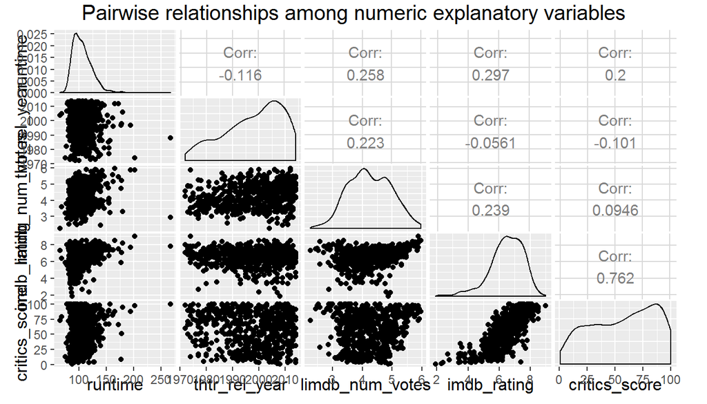

```r
ggpairs(dplyr::select(movies_added_predictors,runtime, thtr_rel_year,limdb_num_votes,imdb_rating,critics_score),title = "Pairwise relationships among numeric explanatory variables")
```

We observed that **imdb_rating** and **critics_score** are highly correlated with correlation coefficient of 0.762, while the rest are not as correlated. Since the two variables are measure of the movie’s popularity, we can compute a weighted average from the two variables to form a new variable **score**.

Since **imdb_rating** is of the range (0,10) and **critics_score** is of the range (0,100), we reweight them by multiply **imdb_rating** with weight 10, and **critics_score** with weight 1, then taking the average of both. The final **score** variable will be of the range (0,100).

```r
movies_added_predictors <- movies_added_predictors %>%
  mutate(score = (imdb_rating*10+critics_score)/2)
```

## Part 4: Modeling

**Bayesian Model Selection using Bayesian Information Criterion (BIC)**

Continue from our explanatory data analysis, we ended up with **13** explanatory variables as listed below. We will use these updated explanatory variables as the full model for our model selection under BIC:

- **feature_film**
- **drama**
- **runtime**
- mpaa_rating_R
- **thtr_rel_year**
- **oscar_season**
- summer_season
- imdb_rating score
- imdb_num_votes limdb_num_votes
- critics_score
- **best_pic_nom**
- **best_pic_win**
- **best_actor_win**
- **best_actress_win**
- **best_dir_win**
- **top200_box**

```r
data_train<-movies_added_predictors %>%
  dplyr::select(audience_score,feature_film,drama,runtime,thtr_rel_year,oscar_season,score,limdb_num_votes,best_pic_nom,best_pic_win,best_actor_win,best_actress_win,best_dir_win,top200_box)
modelFull = lm(audience_score ~ ., data=data_train)

BICmodel<-stepAIC(modelFull,k=log(N))
```

```
## Start:  AIC=3169.18
## audience_score ~ feature_film + drama + runtime + thtr_rel_year +
##     oscar_season + score + limdb_num_votes + best_pic_nom + best_pic_win +
##     best_actor_win + best_actress_win + best_dir_win + top200_box
##
##                    Df Sum of Sq    RSS    AIC
## - oscar_season      1         0  89551 3162.8
## - runtime           1        18  89568 3162.9
## - top200_box        1        36  89586 3163.0
## - best_pic_win      1        55  89606 3163.1
## - best_dir_win      1       234  89784 3164.4
## - best_actor_win    1       316  89867 3164.9
## - best_actress_win  1       337  89888 3165.1
## - best_pic_nom      1       434  89985 3165.7
## - drama             1       820  90371 3168.4
## <none>                           89551 3169.2
## - thtr_rel_year     1      1215  90766 3171.1
## - feature_film      1      3094  92644 3183.8
## - limdb_num_votes   1      5742  95293 3201.2
## - score             1     81420 170971 3563.1
##
## Step:  AIC=3162.75
## audience_score ~ feature_film + drama + runtime + thtr_rel_year +
##     score + limdb_num_votes + best_pic_nom + best_pic_win + best_actor_win +
##     best_actress_win + best_dir_win + top200_box
##
##                    Df Sum of Sq    RSS    AIC
## - runtime           1        19  89570 3156.5
## - top200_box        1        36  89587 3156.6
## - best_pic_win      1        55  89606 3156.7
## - best_dir_win      1       234  89785 3157.9
## - best_actor_win    1       319  89870 3158.5
## - best_actress_win  1       337  89888 3158.7
## - best_pic_nom      1       439  89990 3159.4
## - drama             1       821  90372 3162.0
## <none>                           89551 3162.8
## - thtr_rel_year     1      1215  90766 3164.7
## - feature_film      1      3093  92644 3177.3
## - limdb_num_votes   1      5742  95293 3194.8
## - score             1     81476 171027 3556.8
```

[output cut: 112 more lines]

```
##                   Df Sum of Sq    RSS    AIC
## - thtr_rel_year    1       817  92555 3125.3
## <none>                          91738 3126.3
## - feature_film     1      2477  94215 3136.3
## - limdb_num_votes  1      5204  96941 3154.0
## - score            1     98042 189779 3569.8
##
## Step:  AIC=3125.33
## audience_score ~ feature_film + score + limdb_num_votes
##
##                   Df Sum of Sq    RSS    AIC
## <none>                          92555 3125.3
## - feature_film     1      1854  94409 3131.2
## - limdb_num_votes  1      4399  96954 3147.6
## - score            1    109323 201878 3601.6
```

```r
summary(BICmodel)
```

```
##
## Call:
## lm(formula = audience_score ~ feature_film + score + limdb_num_votes,
##     data = data_train)
##
## Residuals:
##     Min      1Q  Median      3Q     Max
## -35.394  -7.883   0.083   7.447  40.630
##
## Coefficients:
##                 Estimate Std. Error t value Pr(>|t|)
## (Intercept)     -4.77688    3.36055  -1.421  0.15569
## feature_filmno   7.75034    2.20791   3.510  0.00048 ***
## score            0.79197    0.02938  26.952  < 2e-16 ***
## limdb_num_votes  4.22704    0.78187   5.406 9.21e-08 ***
## ---
## Signif. codes:  0 '***' 0.001 '**' 0.01 '*' 0.05 '.' 0.1 ' ' 1
##
## Residual standard error: 12.27 on 615 degrees of freedom
## Multiple R-squared:  0.6321, Adjusted R-squared:  0.6303
## F-statistic: 352.3 on 3 and 615 DF,  p-value: < 2.2e-16
```

The final model includes explanatory variables feature_film, score and limdb_num_votes. 63.03% of the variability of the audience score is explained by this model.

**Model Diagnostics**

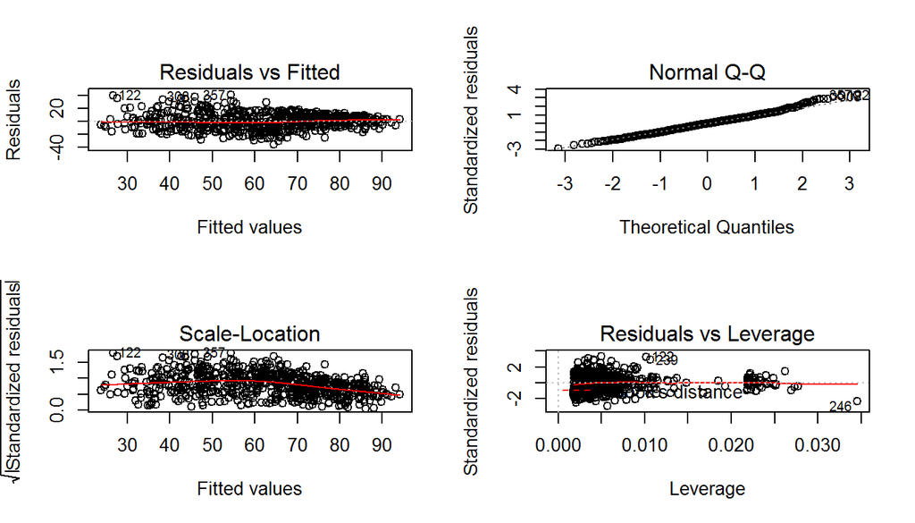

```r
par(mfrow=c(2,2))
plot(BICmodel)
```

Linearity:

Random scatter around zero in residuals vs fitted plot. Hence relationship between response variable and explanatory variables should be linear.

Nearly normal residuals:

Histogram of residual

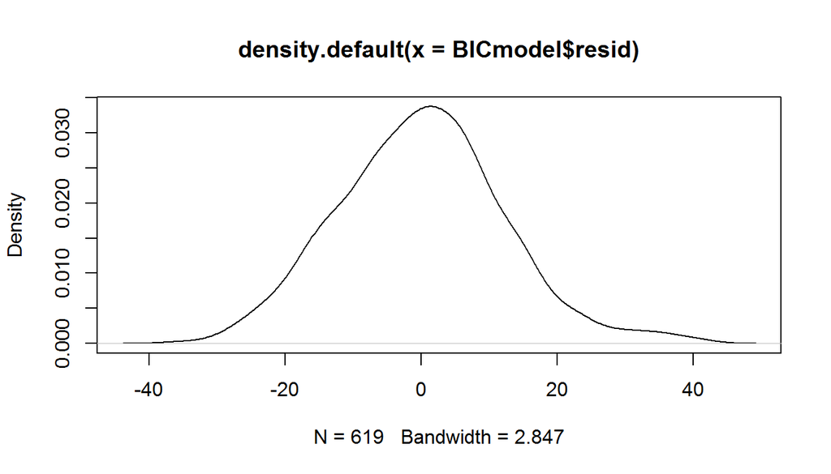

```r
par(mfrow=c(1,1))
plot(density(BICmodel$resid))
```

From the normal probability plot and histogram of residual, the condition for nearly normal residuals is satisfied.

Constant variability:

From the residuals vs fitted plot, the condition for constant variability is also satisfied.

**Bayesian model selection using Bayesian Model Averaging (BMA)**

BMA is created using bas.lm function from the BAS package.

```r
set.seed(5)
bma_audience_score = bas.lm(audience_score ~ .,
                   prior = "BIC",
                   modelprior = uniform(),
                   data=data_train)
bma_audience_score
```

```
##
## Call:
## bas.lm(formula = audience_score ~ ., data = data_train, prior = "BIC",     modelprior = uniform())
##
##
##  Marginal Posterior Inclusion Probabilities:
##           Intercept       feature_filmno              dramano
##             1.00000              0.97204              0.25359
##             runtime        thtr_rel_year       oscar_seasonno
##             0.04289              0.42459              0.03897
##               score      limdb_num_votes      best_pic_nomyes
##             1.00000              0.99991              0.08693
##     best_pic_winyes    best_actor_winyes  best_actress_winyes
##             0.04219              0.09685              0.09570
##     best_dir_winyes        top200_boxyes
##             0.09613              0.04308
```

```r
summary(bma_audience_score)
```

```
##      Intercept feature_filmno dramano runtime thtr_rel_year oscar_seasonno
## [1,]         1              1       0       0             0              0
## [2,]         1              1       0       0             1              0
## [3,]         1              1       1       0             0              0
## [4,]         1              1       1       0             1              0
## [5,]         1              1       0       0             0              0
##      score limdb_num_votes best_pic_nomyes best_pic_winyes
## [1,]     1               1               0               0
## [2,]     1               1               0               0
## [3,]     1               1               0               0
## [4,]     1               1               0               0
## [5,]     1               1               1               0
##      best_actor_winyes best_actress_winyes best_dir_winyes top200_boxyes
## [1,]                 0                   0               0             0
## [2,]                 0                   0               0             0
## [3,]                 0                   0               0             0
## [4,]                 0                   0               0             0
## [5,]                 0                   0               0             0
##              BF PostProbs     R2 dim   logmarg
## [1,] 1.00000000    0.2572 0.6321   4 -3552.162
## [2,] 0.62589879    0.1610 0.6354   5 -3552.630
## [3,] 0.26894022    0.0692 0.6344   5 -3553.475
## [4,] 0.26314802    0.0677 0.6381   6 -3553.497
## [5,] 0.09681019    0.0249 0.6332   5 -3554.497
```

Diagnostic plots for the BMA

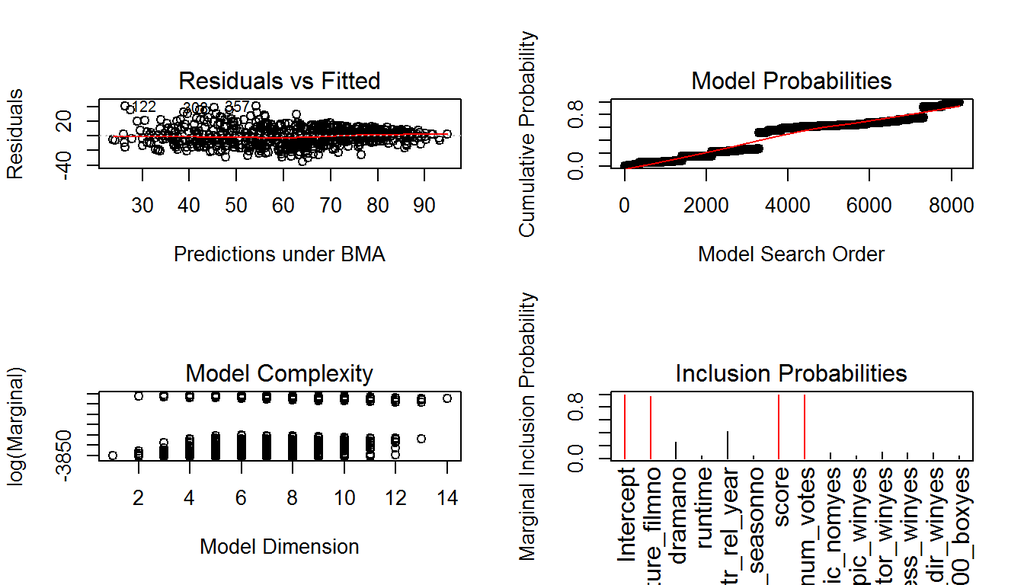

```r
par(mfrow=c(2,2))
plot(bma_audience_score,ask=F)
```

Visualization of model uncertainty

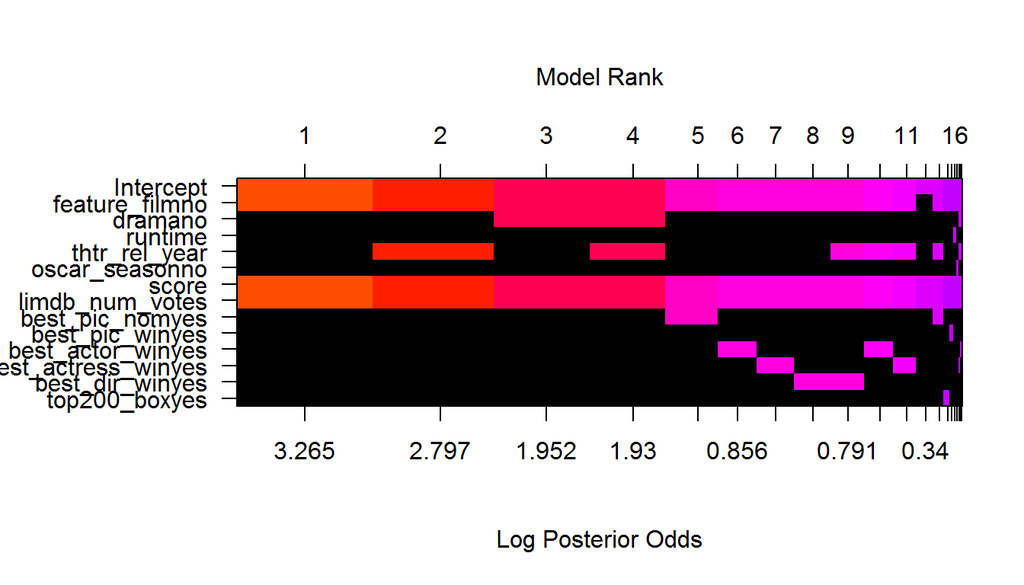

```r
par(mfrow=c(1,1))
image(bma_audience_score,rotate=F)
```

```r
HPM_pred_audience_score = predict(bma_audience_score, estimator="HPM",se.fit=TRUE)
bma_audience_score$namesx[HPM_pred_audience_score$bestmodel+1]
```

```
## [1] "Intercept"       "feature_filmno"  "score"           "limdb_num_votes"
```

**Interpretation of model coefficients**

The 95% credible intervals for the regression coefficients are as follows:

```r
coef_audience_score = coefficients(bma_audience_score)
confint(coef_audience_score)
```

```
##                         2.5  %      97.5  %
## Intercept           61.2270632 63.170708044
## feature_filmno       3.0373382 14.813789017
## dramano             -3.2131678  0.000000000
## runtime              0.0000000  0.000000000
## thtr_rel_year       -0.1807048  0.000000000
## oscar_seasonno       0.0000000  0.000000000
## score                0.7159759  0.848549767
## limdb_num_votes      2.8044762  6.507385867
## best_pic_nomyes      0.0000000  4.131712416
## best_pic_winyes      0.0000000  0.000000000
## best_actor_winyes   -2.1694260  0.000000000
## best_actress_winyes -2.3193440  0.001572246
## best_dir_winyes     -3.1243791  0.000000000
## top200_boxyes        0.0000000  0.000000000
## attr(,"Probability")
## [1] 0.95
```

Visualization of 5 explanatory variables with the highest posterior inclusion probability.

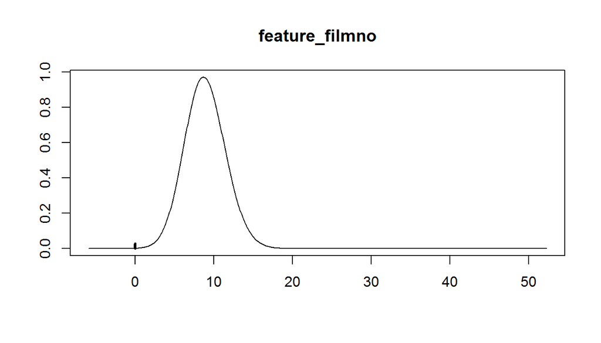

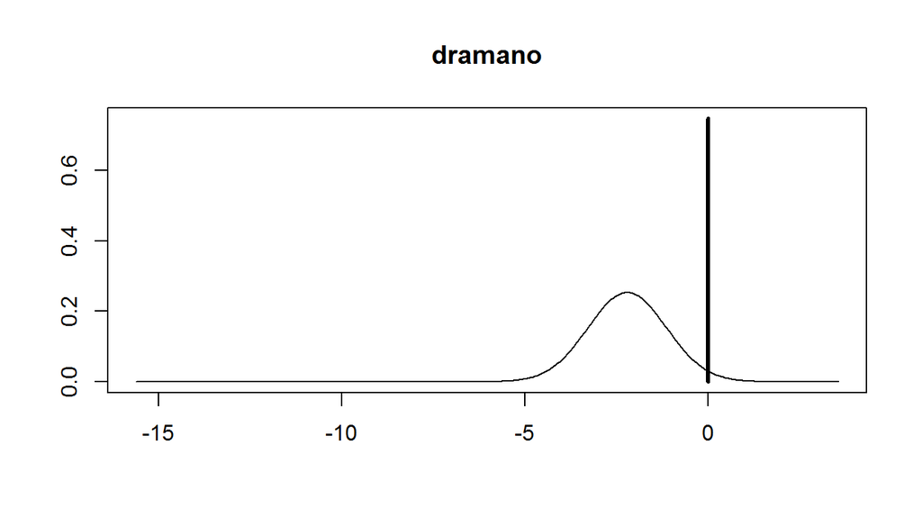

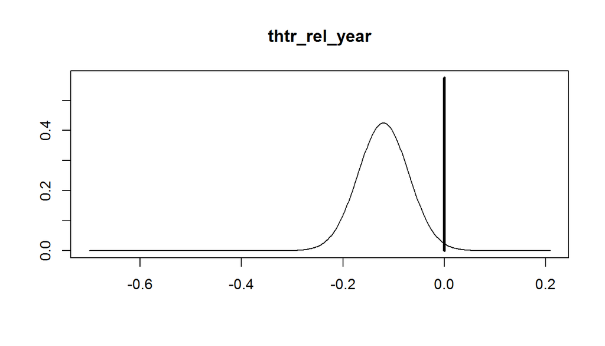

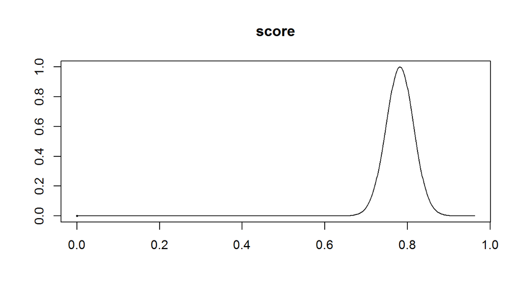

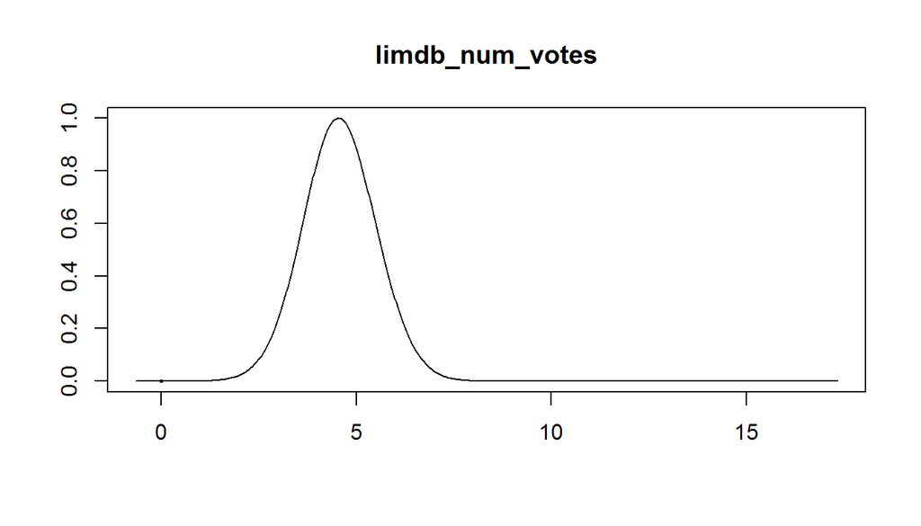

```r
plot(coef_audience_score, subset=c(2,3,5,7,8),  ask=F)
```

From the posterior distribution of coefficients, there are 95% probability that

- All else held constant, feature films have 3.037 to 14.814 point lower in audience score than those that ain’t feature film.
- All else held constant, for each point increment in score increases the audience score from 0.716 to 0.849 point.
- All else held constant, for each point increment in log of IMDb number of vote increases the audience score from 2.804 to 6.507 point.

## Part 5: Prediction

Based on the bayesian multiple regression model we came up with, we would like to predict Rotten Tomatoes’ audience score for the movie “The Martian” of year 2015, which is not in the existing dataset. Below are the related details about the movie:

Movie: **The Martian**

Feature Film: **Yes**

Genre: **Science Fiction & Fantasy** [2]

Release date: **2 October 2015** [2]

Runtime: **164 min** [2]

MPAA Rating: **PG-13** [3]

IMDb Rating: **8.1** [3]

Rotten Tomatoes Critics Score: **92** [2]

Oscar Best Picture Nomination: **Yes** [4]

Oscar Best Picture Won: **No** [4]

Oscar Best Actor Award: **No** [5]

Oscar Best Actress Award: **No** [6]

Oscar Best Director Award: **No** [7]

Top200 Box Office Listing: **No** [8]

From these raw information, the respective explanatory variables for the bayesian model are summarized as follow:

```r
new_movie<-data.frame(audience_score=as.numeric(0),feature_film="yes",drama="no",runtime=as.numeric(164),thtr_rel_year=as.numeric(2015),oscar_season="yes",score=as.numeric(((8.1*10)+92)/2),limdb_num_votes=as.numeric(log10(468482)),best_pic_nom="yes",best_pic_win="no",best_actor_win="no",best_actress_win="no",best_dir_win="no",top200_box="no")
pander(new_movie)
```

Table continues below

| audience_score | feature_film | drama | runtime | thtr_rel_year | oscar_season |
| --- | --- | --- | --- | --- | --- |
| 0 | yes | no | 164 | 2015 | yes |

Table continues below

| score | limdb_num_votes | best_pic_nom | best_pic_win | best_actor_win |
| --- | --- | --- | --- | --- |
| 86.5 | 5.671 | yes | no | no |

| best_actress_win | best_dir_win | top200_box |
| --- | --- | --- |
| no | no | no |

Note that the **audience_score** is initially set to 0, as this is the response variable that we wish to predict.

**Making the prediction**

Prediction using Highest Probability Model

The **new_movie** dataframe is concatenated to the existing training data used to create the bas.lm object, to form a new dataframe, **data_test**. This is then used for prediction.

```r
data_test<-data_train %>%
  rbind(new_movie)

n_new<-nrow(data_test)

set.seed(5)
HPM_pred_audience_score = predict(bma_audience_score, newdata=data_test, estimator="HPM",prediction = TRUE, se.fit=TRUE)

HPM_pred_audience_score$fit[n_new]
```

```
## [1] 87.6992
```

```r
ci_audience_score = confint(HPM_pred_audience_score, estimator="HPM")
ci_audience_score[n_new,]
```

```
##    2.5  %   97.5  %
##  63.48714 111.91126
```

The predicted audience score for the movie “The Martian” using the BIC model, which also corresponds to highest probability model in BMA is 87.70. With 95% probability, the predicted audience score lies between 63.49 and 111.91.

Prediction using Bayesian Model Averaging

In prediction using BMA, multiple models are averaged to obtain posteriors of predictions from new data. Hence it can be considered as a weighted average of prediction from multiple models based on posterior probabilities.

```r
set.seed(5)
BMA_pred_audience_score = predict(bma_audience_score, newdata=data_test, estimator="BMA",prediction = TRUE, se.fit=TRUE)

BMA_pred_audience_score$fit[n_new]
```

```
## [1] 87.08201
```

```r
ci_audience_score = confint(BMA_pred_audience_score,estimator="BMA")
ci_audience_score[n_new,]
```

```
##    2.5  %   97.5  %
##  62.11021 111.05078
```

The predicted audience score for the movie “The Martian” using BMA is 87.08. With 95% probability, the predicted audience score lies between 62.11 and 111.05.

From Rotten Tomatoes, the audience score of the movie “The Martian” retrieved during the writing on this assignment, i.e. 06 Aug, 2016, is 92 [2]. Our predictions with BIC model and BMA of 87.70 and 87.08 respectively, tend to underestimate audience score. However, the actual audience score lies within the 95% credible intervals of (63.49, 111.91) and (62.11, 111.05) for BIC model and BMA respectively.

## Part 6: Conclusion

The BIC model with 3 explanatory variables, namely **feature_film**, **score**, and **limdb_num_votes** has decent performance in predicting audience score of future movies.

We have also compared the prediction and 95% credible interval for a new movie between BIC model and BMA, whereby the results are very close.

One shortcoming of the current study is the limited quantity of explanatory variable for the Bayesian regression and modeling. Apart from that, our current study also did not explore the interaction among the explanatory variables. In future studies, more explanatory variables should be included and also interaction among explanatory variables should be considered.

## References

[1] Codebook for Movies dataset. Retrieved 06 Aug, 2016 Link

[2] The Martian (2015) - Rotten Tomatoes. Retrieved 06 Aug, 2016. [Link](https://www.rottentomatoes.com/m/the_martian/)

[3] The Martian (2015) - IMDb. Retrieved 06 Aug, 2016. [Link](http://www.imdb.com/title/tt3659388/)

[4] The Martian - Awards - IMDb. Retrieve 06 Aug, 2016. [Link](http://www.imdb.com/title/tt3659388/awards)

[5] Matt Damon - Awards - IMDb. Retrieve 06 Aug, 2016. [Link](http://www.imdb.com/name/nm0000354/awards)

[6] Jessica Chastain - Awards - IMDb. Retrieve 06 Aug, 2016. [Link](http://www.imdb.com/name/nm1567113/awards)

[7] Ridley Scott - Awards - IMDb. Retrieve 06 Aug, 2016. [Link](http://www.imdb.com/name/nm0000631/awards)

[8] All Time Box Office Adjusted for Ticket Price Inflation. Retrieved 06 Aug, 2016. [Link](http://www.boxofficemojo.com/alltime/adjusted.htm)